# Data Science Project - Breast Cancer Survival with SEER data

```r
# Display the summary table
summary_table_kable
```

|  | `Race recode (W, B, AI, API)`American Indian/Alaska Native | `Race recode (W, B, AI, API)`Asian or Pacific Islander | `Race recode (W, B, AI, API)`Black | `Race recode (W, B, AI, API)`Unknown | `Race recode (W, B, AI, API)`White | `Primary Site - labeled`C50.1-Central portion of breast | `Primary Site - labeled`C50.2-Upper-inner quadrant of breast | `Primary Site - labeled`C50.3-Lower-inner quadrant of breast | `Primary Site - labeled`C50.4-Upper-outer quadrant of breast | `Primary Site - labeled`C50.5-Lower-outer quadrant of breast | `Primary Site - labeled`C50.6-Axillary tail of breast | `Primary Site - labeled`C50.8-Overlapping lesion of breast | `Primary Site - labeled`C50.9-Breast, NOS | `Grade Recode (thru 2017)`Poorly differentiated; Grade III | `Grade Recode (thru 2017)`Undifferentiated; anaplastic; Grade IV | `Grade Recode (thru 2017)`Unknown | `Grade Recode (thru 2017)`Well differentiated; Grade I | LateralityLeft - origin of primary | LateralityOnly one side - side unspecified | LateralityPaired site, but no information concerning laterality | LateralityRight - origin of primary | `Chemotherapy recode (yes, no/unk)`Yes | `Months from diagnosis to treatment` | `Reason no cancer-directed surgery`Not recommended | `Reason no cancer-directed surgery`Not recommended, contraindicated due to other cond; autopsy only (1973-2002) | `Reason no cancer-directed surgery`Recommended but not performed, patient refused | `Reason no cancer-directed surgery`Recommended but not performed, unknown reason | `Reason no cancer-directed surgery`Recommended, unknown if performed | `Reason no cancer-directed surgery`Surgery performed | … |
| --- | --- | --- | --- | --- | --- | --- | --- | --- | --- | --- | --- | --- | --- | --- | --- | --- | --- | --- | --- | --- | --- | --- | --- | --- | --- | --- | --- | --- | --- | --- |
|  | Min. :-0.1576838 | Min. :-0.6165221 | Min. :-0.673943 | Min. :-0.1334814 | Min. :-0.6739426 | Min. :-0.155876 | Min. :-0.2615058 | Min. :-0.169973 | Min. :-0.382989 | Min. :-0.199024 | Min. :-0.0520480 | Min. :-0.382989 | Min. :-0.275063 | Min. :-0.3318287 | Min. :-0.0208938 | Min. :-0.204073 | Min. :-0.331829 | Min. :-0.9935062 | Min. :-0.0366469 | Min. :-0.1575071 | Min. :-0.9935062 | Min. :-0.284581 | Min. :-0.071647 | Min. :-0.8574575 | Min. :-0.2202216 | Min. :-0.248924 | Min. :-0.1439998 | Min. :-0.306675 | Min. :-0.857457 | … |
|  | 1st Qu.:-0.0020006 | 1st Qu.:-0.0202167 | 1st Qu.:-0.012099 | 1st Qu.:-0.0058338 | 1st Qu.:-0.0189862 | 1st Qu.:-0.010531 | 1st Qu.:-0.0055591 | 1st Qu.:-0.005036 | 1st Qu.:-0.007592 | 1st Qu.:-0.004752 | 1st Qu.:-0.0033956 | 1st Qu.:-0.005180 | 1st Qu.:-0.012712 | 1st Qu.:-0.0102566 | 1st Qu.:-0.0020484 | 1st Qu.:-0.005608 | 1st Qu.:-0.011881 | 1st Qu.:-0.0025589 | 1st Qu.:-0.0026654 | 1st Qu.:-0.0054651 | 1st Qu.:-0.0025611 | 1st Qu.:-0.008157 | 1st Qu.:-0.009361 | 1st Qu.:-0.0113926 | 1st Qu.:-0.0066137 | 1st Qu.:-0.005443 | 1st Qu.:-0.0023943 | 1st Qu.:-0.008606 | 1st Qu.:-0.012623 | … |
|  | Median : 0.0005336 | Median :-0.0033835 | Median : 0.001860 | Median :-0.0006944 | Median :-0.0007078 | Median :-0.001262 | Median :-0.0028889 | Median :-0.001448 | Median :-0.001242 | Median :-0.002111 | Median :-0.0003168 | Median :-0.001220 | Median : 0.000506 | Median :-0.0009646 | Median :-0.0002264 | Median : 0.002904 | Median :-0.001414 | Median :-0.0004302 | Median :-0.0004554 | Median :-0.0002511 | Median : 0.0002321 | Median : 0.003513 | Median :-0.002447 | Median :-0.0019345 | Median :-0.0007267 | Median :-0.001201 | Median :-0.0000559 | Median :-0.001012 | Median : 0.000035 | … |
|  | Mean : 0.0169704 | Mean :-0.0009204 | Mean : 0.005789 | Mean : 0.0107475 | Mean :-0.0088807 | Mean : 0.005178 | Mean : 0.0001063 | Mean : 0.004543 | Mean :-0.006328 | Mean : 0.002687 | Mean : 0.0103478 | Mean :-0.003984 | Mean : 0.003542 | Mean : 0.0100118 | Mean : 0.0125342 | Mean : 0.012084 | Mean : 0.001227 | Mean :-0.0009544 | Mean : 0.0126757 | Mean : 0.0127019 | Mean :-0.0007810 | Mean : 0.016328 | Mean : 0.008602 | Mean : 0.0009881 | Mean : 0.0085826 | Mean : 0.008312 | Mean : 0.0118276 | Mean : 0.008002 | Mean :-0.010200 | … |
|  | 3rd Qu.: 0.0040061 | 3rd Qu.: 0.0070447 | 3rd Qu.: 0.016525 | 3rd Qu.: 0.0047715 | 3rd Qu.: 0.0125200 | 3rd Qu.: 0.005010 | 3rd Qu.: 0.0011539 | 3rd Qu.: 0.004086 | 3rd Qu.: 0.004650 | 3rd Qu.: 0.001679 | 3rd Qu.: 0.0022560 | 3rd Qu.: 0.002721 | 3rd Qu.: 0.012246 | 3rd Qu.: 0.0092260 | 3rd Qu.: 0.0026775 | 3rd Qu.: 0.009980 | 3rd Qu.: 0.007513 | 3rd Qu.: 0.0014938 | 3rd Qu.: 0.0015396 | 3rd Qu.: 0.0030307 | 3rd Qu.: 0.0022817 | 3rd Qu.: 0.022748 | 3rd Qu.: 0.005722 | 3rd Qu.: 0.0066273 | 3rd Qu.: 0.0027397 | 3rd Qu.: 0.002368 | 3rd Qu.: 0.0043855 | 3rd Qu.: 0.004974 | 3rd Qu.: 0.009365 | … |
|  | Max. : 1.0000000 | Max. : 1.0000000 | Max. : 1.000000 | Max. : 1.0000000 | Max. : 1.0000000 | Max. : 1.000000 | Max. : 1.0000000 | Max. : 1.000000 | Max. : 1.000000 | Max. : 1.000000 | Max. : 1.0000000 | Max. : 1.000000 | Max. : 1.000000 | Max. : 1.0000000 | Max. : 1.0000000 | Max. : 1.000000 | Max. : 1.000000 | Max. : 1.0000000 | Max. : 1.0000000 | Max. : 1.0000000 | Max. : 1.0000000 | Max. : 1.000000 | Max. : 1.000000 | Max. : 1.0000000 | Max. : 1.0000000 | Max. : 1.000000 | Max. : 1.0000000 | Max. : 1.000000 | Max. : 1.000000 | … |
|  | NA’s :1 | NA’s :1 | NA’s :1 | NA’s :1 | NA’s :1 | NA’s :1 | NA’s :1 | NA’s :1 | NA’s :1 | NA’s :1 | NA’s :1 | NA’s :1 | NA’s :1 | NA’s :1 | NA’s :1 | NA’s :1 | NA’s :1 | NA’s :1 | NA’s :1 | NA’s :1 | NA’s :1 | NA’s :1 | NA’s :1 | NA’s :1 | NA’s :1 | NA’s :1 | NA’s :1 | NA’s :1 | NA’s :1 | … |

[figure not shown]

```r
# Extract correlation with COD
correlation_with_COD <- correlation_matrix[, "COD"]

# Convert correlation_with_COD to a data frame with column names
correlation_df <- data.frame(variable = names(correlation_with_COD), correlation = correlation_with_COD)

# Sort correlation values
correlation_df <- correlation_df[order(correlation_df$correlation, decreasing = TRUE), ]

# Create bar plot using ggplot2
ggplot(correlation_df, aes(x = variable, y = correlation)) +
  geom_bar(stat = "identity") +
  labs(title = "Correlation with COD", x = "Variables", y = "Correlation")
```

```r
# Find the index of the column named "COD"
cod_column_index <- which(names(BREAST_DF_surv_clean) == "COD")

# Exclude "COD" column from model matrix and encode factors
encoded_data <- predict(dummyVars(" ~ .", data = BREAST_DF_surv_clean[, -cod_column_index], fullRank = TRUE), newdata = BREAST_DF_surv_clean)



# Remove the "COD" column from encoded_data
encoded_data <- encoded_data[, -cod_column_index]

# Add "COD" column back to encoded_data
encoded_data <- cbind(encoded_data, COD = BREAST_DF_surv_clean$COD)

# Calculate correlation matrix
correlation_matrix <- cor(encoded_data)

# Extract correlation with COD
correlation_with_COD <- correlation_matrix[, "COD"]

# Summary of correlation matrix
summary(correlation_matrix)
```

```
##  `Race recode (W, B, AI, API)`Asian or Pacific Islander
##  Min.   :-0.611482
##  1st Qu.:-0.020636
##  Median :-0.004543
##  Mean   :-0.001203
##  3rd Qu.: 0.006915
##  Max.   : 1.000000
##  NA's   :3
##  `Race recode (W, B, AI, API)`Black `Race recode (W, B, AI, API)`Unknown
##  Min.   :-0.672898                  Min.   :-0.151550
##  1st Qu.:-0.008186                  1st Qu.:-0.008196
##  Median : 0.002961                  Median :-0.001720
##  Mean   : 0.007238                  Mean   : 0.011140
##  3rd Qu.: 0.015977                  3rd Qu.: 0.004775
##  Max.   : 1.000000                  Max.   : 1.000000
##  NA's   :3                          NA's   :3
##  `Race recode (W, B, AI, API)`White
##  Min.   :-0.672898
##  1st Qu.:-0.021506
##  Median :-0.001173
##  Mean   :-0.007624
##  3rd Qu.: 0.013379
##  Max.   : 1.000000
##  NA's   :3
##  `Primary Site - labeled`C50.1-Central portion of breast
##  Min.   :-0.152121
##  1st Qu.:-0.009934
##  Median :-0.002113
##  Mean   : 0.005421
##  3rd Qu.: 0.006062
##  Max.   : 1.000000
##  NA's   :3
##  `Primary Site - labeled`C50.2-Upper-inner quadrant of breast
##  Min.   :-0.253678
##  1st Qu.:-0.009990
##  Median :-0.003675
##  Mean   :-0.001860
##  3rd Qu.: 0.000150
##  Max.   : 1.000000
##  NA's   :3
```

[output cut: 521 more lines]

```
##  Min.   :-0.1497345                      Min.   :-0.185038
##  1st Qu.:-0.0260547                      1st Qu.:-0.032765
##  Median :-0.0009538                      Median :-0.002749
##  Mean   : 0.0030973                      Mean   : 0.009643
##  3rd Qu.: 0.0066626                      3rd Qu.: 0.005992
##  Max.   : 1.0000000                      Max.   : 1.000000
##  NA's   :3                               NA's   :3
##  Radiation.Yes           COD
##  Min.   :-0.18043   Min.   :-0.274122
##  1st Qu.:-0.02974   1st Qu.:-0.028538
##  Median :-0.00240   Median : 0.003475
##  Mean   : 0.00561   Mean   : 0.019223
##  3rd Qu.: 0.01477   3rd Qu.: 0.028403
##  Max.   : 1.00000   Max.   : 1.000000
##  NA's   :3          NA's   :3
```

```r
# Print correlation with COD
print(correlation_with_COD)
```

```
##                                                          `Race recode (W, B, AI, API)`Asian or Pacific Islander
##                                                                                                   -0.0545190384
##                                                                              `Race recode (W, B, AI, API)`Black
##                                                                                                    0.0469532442
##                                                                            `Race recode (W, B, AI, API)`Unknown
##                                                                                                   -0.0293993259
##                                                                              `Race recode (W, B, AI, API)`White
##                                                                                                    0.0074658579
##                                                         `Primary Site - labeled`C50.1-Central portion of breast
##                                                                                                    0.0250324542
##                                                    `Primary Site - labeled`C50.2-Upper-inner quadrant of breast
##                                                                                                   -0.0331489825
##                                                    `Primary Site - labeled`C50.3-Lower-inner quadrant of breast
##                                                                                                   -0.0090667775
##                                                    `Primary Site - labeled`C50.4-Upper-outer quadrant of breast
##                                                                                                   -0.0443648371
##                                                    `Primary Site - labeled`C50.5-Lower-outer quadrant of breast
##                                                                                                   -0.0175945778
##                                                           `Primary Site - labeled`C50.6-Axillary tail of breast
##                                                                                                    0.0043188952
##                                                      `Primary Site - labeled`C50.8-Overlapping lesion of breast
##                                                                                                   -0.0110631898
##                                                                       `Primary Site - labeled`C50.9-Breast, NOS
##                                                                                                    0.1016503665
##                                                      `Grade Recode (thru 2017)`Poorly differentiated; Grade III
##                                                                                                    0.0271874011
##                                                `Grade Recode (thru 2017)`Undifferentiated; anaplastic; Grade IV
##                                                                                                    0.0094420265
##                                                                               `Grade Recode (thru 2017)`Unknown
##                                                                                                    0.0968239858
##                                                          `Grade Recode (thru 2017)`Well differentiated; Grade I
##                                                                                                   -0.0623106812
##                                                                     Laterality.Only one side - side unspecified
##                                                                                                    0.0200049734
##                                                Laterality.Paired site, but no information concerning laterality
##                                                                                                    0.1028374128
##                                                                            Laterality.Right - origin of primary
##                                                                                                   -0.0181205661
##                                                                          `Chemotherapy recode (yes, no/unk)`Yes
##                                                                                                   -0.0921253574
```

[output cut: 99 more lines]

```
##                                                                                                   -0.0661892685
##                                                                         `Age recode (<60,60-69,70+)`65-69 years
##                                                                                                   -0.0379863553
##                                                                         `Age recode (<60,60-69,70+)`70-74 years
##                                                                                                    0.0251230157
##                                                                         `Age recode (<60,60-69,70+)`75-79 years
##                                                                                                    0.1002552651
##                                                                         `Age recode (<60,60-69,70+)`80-84 years
##                                                                                                    0.1861215456
##                                                                           `Age recode (<60,60-69,70+)`85+ years
##                                                                                                    0.3114860645
##                                                                                                   Radiation.Yes
##                                                                                                   -0.1573241890
##                                                                                                             COD
##                                                                                                    1.0000000000
```

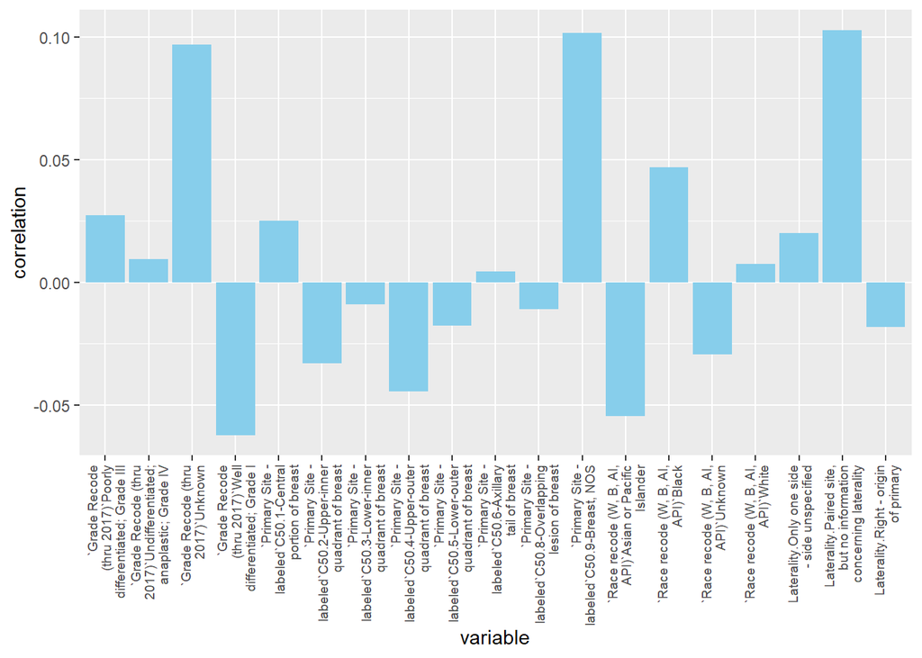

```r
# Exclude "COD" column from model matrix and encode factors
encoded_data <- predict(dummyVars(" ~ .", data = BREAST_DF_surv_clean[, -cod_column_index], fullRank = TRUE), newdata = BREAST_DF_surv_clean)

# Alternatively, using ggplot
correlation_df <- data.frame(variable = colnames(correlation_matrix), correlation = correlation_with_COD)
# Create a ggplot with facets
ggplot(correlation_df[1:19, ], aes(x = variable, y = correlation)) +
  geom_bar(stat = "identity", fill = "skyblue") +
  theme(axis.text.x = element_text(angle = 90, vjust = 0.5, hjust = 1,
                                   size = 7)) +  # Adjust size as needed
  scale_x_discrete(labels = function(x) str_wrap(x, width = 25))  # Wrap text
```

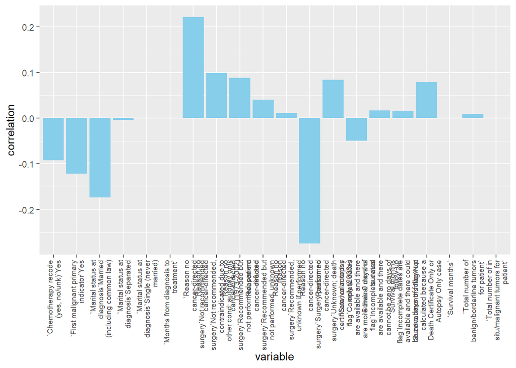

```r
ggplot(correlation_df[20:39, ], aes(x = variable, y = correlation)) +
  geom_bar(stat = "identity", fill = "skyblue") +
  theme(axis.text.x = element_text(angle = 90, vjust = 0.5, hjust = 1,
                                   size = 7)) +  # Adjust size as needed
  scale_x_discrete(labels = function(x) str_wrap(x, width = 25))  # Wrap text
```

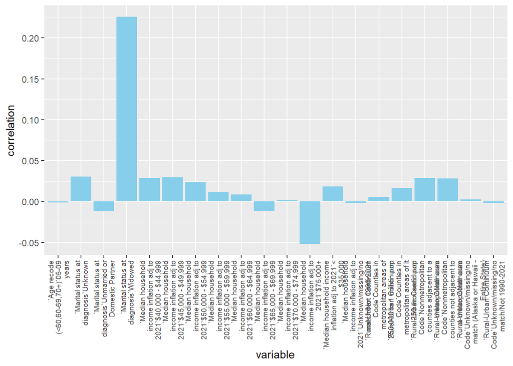

```r
ggplot(correlation_df[40:59, ], aes(x = variable, y = correlation)) +
  geom_bar(stat = "identity", fill = "skyblue") +
  theme(axis.text.x = element_text(angle = 90, vjust = 0.5, hjust = 1,
                                   size = 7)) +  # Adjust size as needed
  scale_x_discrete(labels = function(x) str_wrap(x, width = 25))  # Wrap text
```

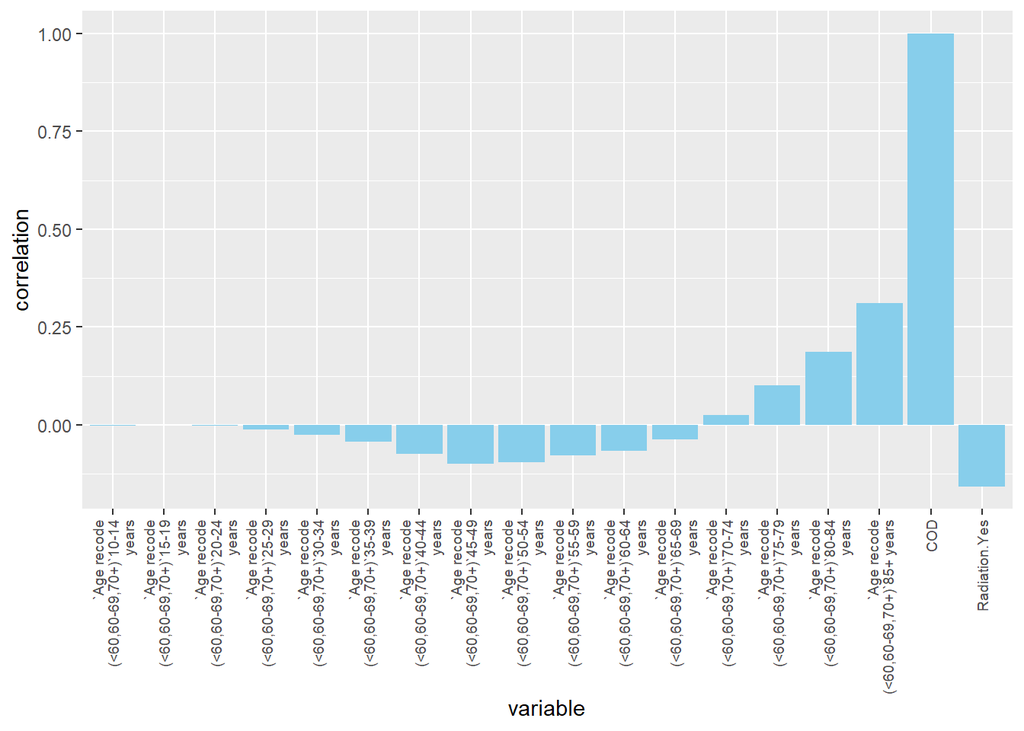

```r
ggplot(correlation_df[60:77, ], aes(x = variable, y = correlation)) +
  geom_bar(stat = "identity", fill = "skyblue") +
  theme(axis.text.x = element_text(angle = 90, vjust = 0.5, hjust = 1,
                                   size = 7)) +  # Adjust size as needed
  scale_x_discrete(labels = function(x) str_wrap(x, width = 25))  # Wrap text
```

## Machine learning, Random Forest classification model

To be able to work with this database, I need to transform the categorical data (factors) to numerical variables. A method known as one-hot encoding is used. Although for this survival analysis, target encoding is the better method, I have decided not to apply that due to complexity and time constraints [1,2].

In general the machine learning phase consist of four main steps:

1. Encode categorical variables.
2. Split the data into training and testing sets.
3. Train the models.
4. Evaluate the models.

### What is target encoding:

Target encoding, also known as mean encoding or likelihood encoding, is a technique used to encode categorical variables into numerical values based on the target variable. It replaces each category with the mean (or some other summary statistic) of the target variable for that category. `caret` is the package in R that has this function embedded.

### What is One-Hot encoding:

One-hot encoding is a technique used in classification tasks to represent categorical variables, such as alive or deceased in the case of survival analysis, as binary vectors. In R, this is achieved by converting each category into a binary vector where each element corresponds to a category, with a value of 1 indicating the presence of the category and 0 otherwise. This allows machine learning algorithms to effectively interpret and utilize categorical data in predictive models.

### Different models investigated in this Project

1. **Random Forest (`rf`):** Random forest is a popular machine learning algorithm that can be adapted for survival analysis. It constructs a multitude of decision trees during training and outputs the mode of the classes (classification) or the mean prediction (regression) of the individual trees.
2. **Logistic Regression (`glm`):** Logistic regression, a foundational technique in survival analysis, is employed in this project to model the relationship between various prognostic factors and the probability of survival or death outcomes in breast cancer patients.
3. **Deep Nueral Netweork (DNN):** This is a a powerful machine learning model that can learn complex patterns in data to classify individuals as either alive or deceased in a given classification problem. In R, DNNs can be implemented using packages like `keras`, providing a flexible framework for building and training deep learning models tailored to specific datasets.

### Data Preparation for Resemble models

```r
BREAST_DF_surv_clean_no_missing <- na.omit(BREAST_DF_surv_clean)

#change the problem to a binomial distribution of Alive / Breast and remove others, Binimonal is easier to tackle
#Repalce also factor to numer 1 and 2 from "Alive" and "Breast"
# Remove "Others" from COD column
BREAST_DF_surv_clean_no_missing_bi <- BREAST_DF_surv_clean_no_missing[BREAST_DF_surv_clean_no_missing$COD != "Other", ]

# Replace remaining categories with numerical values
#BREAST_DF_surv_clean_no_missing_bi$COD <- as.numeric(factor(BREAST_DF_surv_clean_no_missing_bi$COD, levels = c("Alive", "Breast")))

BREAST_DF_surv_clean_no_missing_bi$COD <- ifelse(BREAST_DF_surv_clean_no_missing_bi$COD == "Alive", 1, 0)

BREAST_DF_surv_clean_no_missing_bi$COD <- as.factor(BREAST_DF_surv_clean_no_missing_bi$COD)

# Convert to binomial distribution
#model_rf <- randomForest(COD ~ ., data = BREAST_DF_surv_clean_no_missing_bi, type = "response", ntree = 100)


# Find the index of the column named "COD"
cod_column_index <- which(names(BREAST_DF_surv_clean_no_missing_bi) == "COD")

# Exclude "COD" column from the data
data_without_cod <- BREAST_DF_surv_clean_no_missing_bi[, -cod_column_index]

# Perform one-hot encoding
encoded_data <- dummyVars(" ~ .", data = data_without_cod)

# Create the design matrix with encoded data
design_matrix <- predict(encoded_data, newdata = data_without_cod)
design_matrix <- data.frame(design_matrix)

# Add the target variable (COD) back to the design matrix
design_matrix <- cbind(design_matrix, COD = BREAST_DF_surv_clean_no_missing_bi$COD)
design_matrix$COD <- factor(design_matrix$COD)

# Split the data into training and testing sets
set.seed(123)  # for reproducibility
train_indices <- createDataPartition(design_matrix$COD, p = 0.7, list = FALSE)
train_data <- design_matrix[train_indices, ]
test_data <- design_matrix[-train_indices, ]
```

### Machine Learning: Random Forest

Random Forests are a powerful machine learning technique well-suited for survival analysis tasks like predicting patient survival in cancer cases. Random Forests don’t rely on a single decision tree but on a multitude of them (“forest”). Each tree is built on a random subset of the data (with replacement) and uses a random selection of features at each split.

```r
# Fit the Random Forest model
model_rf <- randomForest(COD ~ ., data = train_data, type = "prob")

# Make predictions on the test set
predictions_rf <- predict(model_rf, newdata = test_data)

# Evaluate the model
conf_matrix <- confusionMatrix(predictions_rf, test_data$COD)
print(conf_matrix)
```

```
## Confusion Matrix and Statistics
##
##           Reference
## Prediction     0     1
##          0  6970  1479
##          1  2591 65338
##
##                Accuracy : 0.9467
##                  95% CI : (0.9451, 0.9483)
##     No Information Rate : 0.8748
##     P-Value [Acc > NIR] : < 2.2e-16
##
##                   Kappa : 0.7439
##
##  Mcnemar's Test P-Value : < 2.2e-16
##
##             Sensitivity : 0.72900
##             Specificity : 0.97786
##          Pos Pred Value : 0.82495
##          Neg Pred Value : 0.96186
##              Prevalence : 0.12518
##          Detection Rate : 0.09126
##    Detection Prevalence : 0.11062
##       Balanced Accuracy : 0.85343
##
##        'Positive' Class : 0
##
```

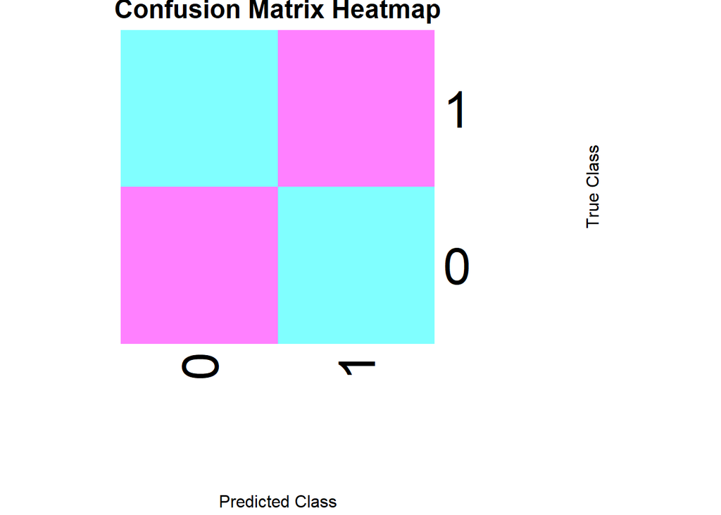

```r
# Plot confusion matrix as a heatmap
conf_table <- as.table(conf_matrix$table)
heatmap(conf_table,
        Colv = NA,
        Rowv = NA,
        col = cm.colors(12),
        scale = "column",
        margins = c(10, 10),
        xlab = "Predicted Class",
        ylab = "True Class",
        main = "Confusion Matrix Heatmap")
```

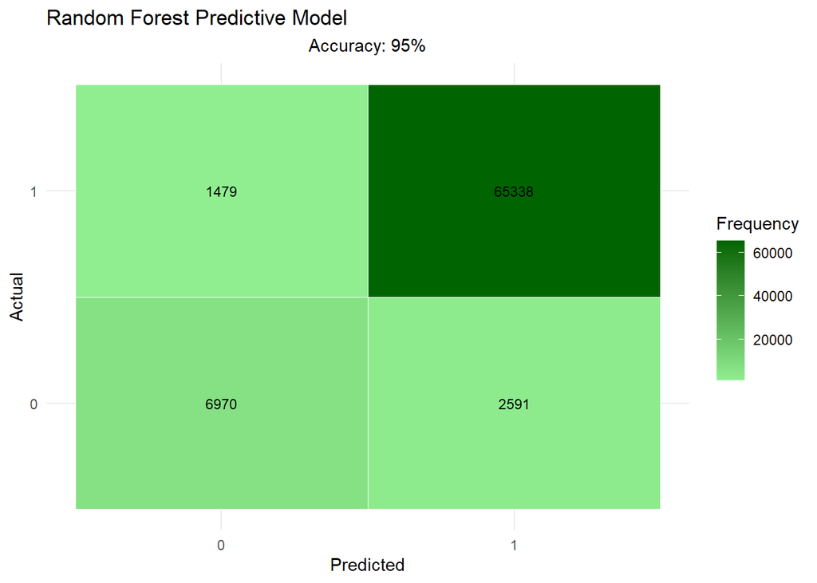

```r
# Heatmap
heatmap_data <- as.data.frame(as.table(conf_matrix))
heatmap <- ggplot(heatmap_data, aes(x = Prediction, y = Reference, fill = Freq)) +
  geom_tile(color = "white") +
  scale_fill_gradient(low = "lightgreen", high = "darkgreen") +
  labs(x = "Predicted", y = "Actual", fill = "Frequency") +
  theme_minimal() +
  geom_text(aes(label = Freq), color = "black", size = 3) +  # Add text labels
  ggtitle("Random Forest Predictive Model") +  # Add title
  labs(subtitle = paste("Accuracy:", scales::percent(conf_matrix$overall["Accuracy"]))) +  # Add accuracy as subtitle
  theme(plot.subtitle = element_text(hjust = 0.5))  # Center subtitle

print(heatmap)
```

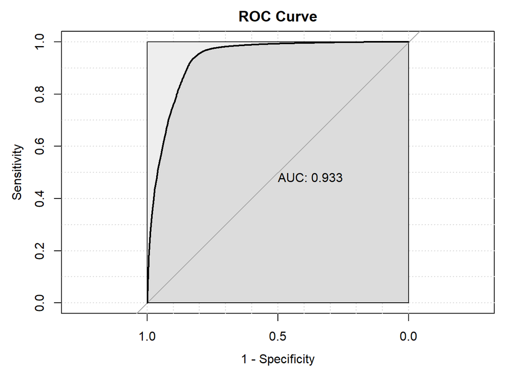

```r
# Get predicted probabilities for each class (ensure type="prob" is used)
predictions_rf_probs <- predict(model_rf, test_data, type = "prob")

# Extract true class labels and convert them to factor
true_class <- as.factor(test_data$COD)

# Convert factor predictions to ordered factors
predictions_order <- ordered(as.numeric(predictions_rf) - 1, levels = c(0, 1))

# Create ROC curve
roc_curve <- roc(true_class, predictions_rf_probs[, "1"])
# Plot ROC curve
plot(roc_curve, print.auc = TRUE, auc.polygon = TRUE, max.auc.polygon = TRUE, grid = TRUE, grid.col = "lightgray", main = "ROC Curve", xlab = "1 - Specificity", ylab = "Sensitivity")
```

### Machine Learning: Logistic Regression

Logistic regression is a statistical model used to analyze the relationship between a binary outcome variable and one or more independent variables. It estimates the probability of the outcome variable being in a particular category (usually coded as 0 or 1) based on the values of the independent variables. The model employs the logistic function to constrain the predicted probabilities between 0 and 1, making it suitable for binary classification tasks like survival/death analyses in our case. In R, logistic regression can be implemented using the glm() function with a binomial family distribution.

```r
# Train the logistic regression model
logistic_model <- glm(COD ~ ., data = train_data, family = binomial)

# Make predictions on the test set
predictions_logistic <- predict(logistic_model, newdata = test_data, type = "response")
# Convert predicted probabilities to class labels
predicted_class <- ifelse(predictions_logistic > 0.5, 1, 0)

# Evaluate the model
confusion_matrix <- table(predicted_class, test_data$COD)
print(confusion_matrix)
```

```
##
## predicted_class     0     1
##               0  5755  1538
##               1  3806 65279
```

```r
# Calculate accuracy
accuracy <- sum(diag(confusion_matrix)) / sum(confusion_matrix)
print(paste("Accuracy:", accuracy))
```

```
## [1] "Accuracy: 0.9300322082275"
```

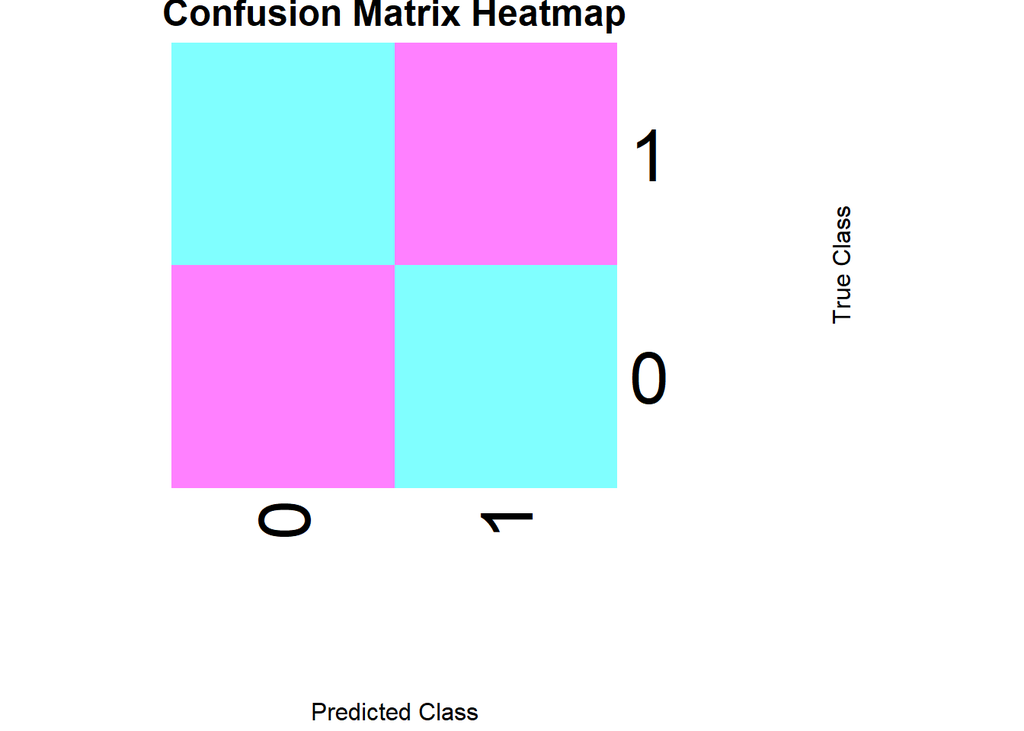

```r
# Plot the confusion matrix as a heatmap
heatmap(confusion_matrix,
        Colv = NA,
        Rowv = NA,
        col = cm.colors(12),  # Color palette for heatmap
        scale = "column",     # Scale rows (predictions)
        margins = c(10, 10),  # Add extra space for row and column names
        xlab = "Predicted Class",
        ylab = "True Class",
        main = "Confusion Matrix Heatmap")
```

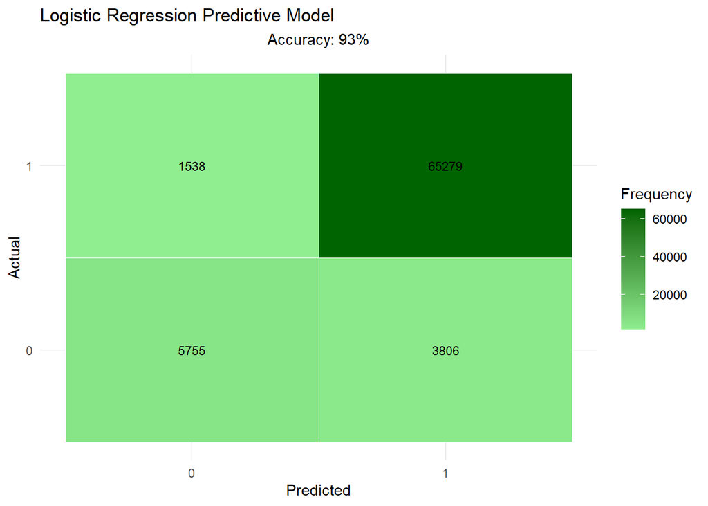

```r
# Heatmap
heatmap_data <- as.data.frame(as.table(confusion_matrix))
heatmap <- ggplot(heatmap_data, aes(x = predicted_class, y = Var2, fill = Freq)) +
  geom_tile(color = "white") +
  scale_fill_gradient(low = "lightgreen", high = "darkgreen") +
  labs(x = "Predicted", y = "Actual", fill = "Frequency") +
  theme_minimal() +
  geom_text(aes(label = Freq), color = "black", size = 3) +  # Add text labels
  ggtitle("Logistic Regression Predictive Model") +  # Add title
  labs(subtitle = paste("Accuracy:", scales::percent(accuracy))) +  # Add accuracy as subtitle
  theme(plot.subtitle = element_text(hjust = 0.5))  # Center subtitle

print(heatmap)
```

```r
# Calculate AUC ROC
roc_curve <- roc(test_data$COD, predictions_logistic)
print(roc_curve)
```

```
##
## Call:
## roc.default(response = test_data$COD, predictor = predictions_logistic)
##
## Data: predictions_logistic in 9561 controls (test_data$COD 0) < 66817 cases (test_data$COD 1).
## Area under the curve: 0.9291
```

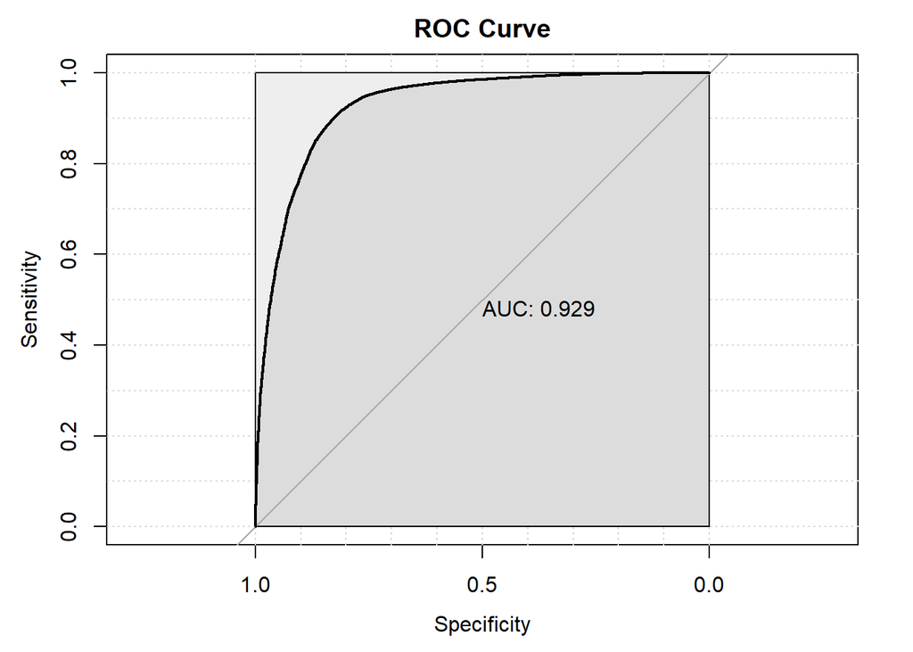

```r
# Plot the ROC curve
plot(roc_curve, print.auc = TRUE, auc.polygon = TRUE, max.auc.polygon = TRUE, grid = TRUE, grid.col = "lightgray", main = "ROC Curve")
```

### Data Preparation for Survival model

```r
# Prepare data
cod_column_index_1 <- which(names(BREAST_DF_surv_clean_no_missing) == c("COD","Survival months"))


# Exclude "COD" column from the data
#data_without_cod <- BREAST_DF_surv_clean[, -cod_column_index]
data_without_cod_1 <- BREAST_DF_surv_clean_no_missing[, -cod_column_index]

# Perform one-hot encoding
encoded_data_1 <- dummyVars(" ~ .", data = data_without_cod_1)

# Create the design matrix with encoded data
design_matrix_1 <- predict(encoded_data_1, newdata = data_without_cod_1)

# Add the target variable (Survival months and status) back to the design matrix
design_matrix_1 <- cbind(design_matrix_1,
                       Time = BREAST_DF_surv_clean_no_missing$`Survival months`,
                       Status = BREAST_DF_surv_clean_no_missing$COD)
design_matrix_1 <- data.frame(design_matrix_1)

# Split the data into training and testing sets
set.seed(123)  # for reproducibility
train_indices_1 <- createDataPartition(design_matrix_1$Status, p = 0.7, list = FALSE)
train_data_1 <- design_matrix_1[train_indices, ]
test_data_1 <- design_matrix_1[-train_indices, ]
```

### Deep Neural Network (DNN)

A deep neural network for survival analysis is a powerful machine learning model capable of capturing complex patterns in survival data to predict the likelihood of an event occurring (e.g., death) over a given period. In binary classification tasks such as life/dead outcomes, a deep neural network consists of multiple layers of interconnected nodes (neurons) that process input features to predict the probability of an individual experiencing the event of interest. These networks can incorporate various architectures, such as convolutional neural networks (CNNs) or recurrent neural networks (RNNs), and are trained using optimization algorithms like stochastic gradient descent (SGD) to minimize prediction errors. In R, deep neural networks for survival analysis can be implemented using libraries like keras or tensorflow, allowing for flexible modeling and customization.

```r
# Load required libraries
library(keras)
library(survival)
library(survMisc)  # For cindex() function
```

```r
library(reticulate)
#use_python("C:/Users/kohya/AppData/Local/Programs/Python/Python37")
# Define the neural network architecture
model <- keras_model_sequential() %>%
  layer_dense(units = 64, activation = "relu", input_shape = ncol(train_data) - 1) %>%
  layer_dense(units = 32, activation = "relu") %>%
  layer_dense(units = 1, activation = "sigmoid")

# Compile the model
model %>% compile(
  loss = "binary_crossentropy",
  optimizer = optimizer_adam(),
  metrics = c("accuracy")
)

# Train the model
history <- model %>% fit(
  x = as.matrix(train_data[, -ncol(train_data)]),  # Features
  y = as.numeric(train_data$COD) - 1,  # Target variable (convert to 0-based index)
  epochs = 100,
  batch_size = 32,
  validation_split = 0.2
)
```

[output not shown]

[output cut: 45 more lines]

[output not shown]

```r
# Evaluate the model
metrics <- model %>% evaluate(
  x = as.matrix(test_data[, -ncol(test_data)]),  # Features
  y = as.numeric(test_data$COD) - 1,  # Target variable (convert to 0-based index)
  verbose = 0
)

# Print evaluation metrics
cat("Test Loss:", metrics["loss"], "\n")
```

```
## Test Loss: 0.2614014
```

```r
cat("Test Accuracy:", metrics["accuracy"], "\n")
```

```
## Test Accuracy: 0.9416193
```

```r
# Predictions on test data
predictions <- model %>% predict(as.matrix(test_data[, -ncol(test_data)]))
```

```
## 2387/2387 - 2s - 2s/epoch - 1ms/step
```

```r
predictions <- ifelse(predictions > 0.5, 1, 0)

# Confusion matrix
conf_matrix <- table(Actual = as.numeric(test_data$COD) - 1, Predicted = predictions)
print("Confusion Matrix:")
```

```
## [1] "Confusion Matrix:"
```

```r
print(conf_matrix)
```

```
##       Predicted
## Actual     0     1
##      0  6565  2996
##      1  1463 65354
```

```r
# Accuracy, Sensitivity, and Specificity
accuracy <- sum(diag(conf_matrix)) / sum(conf_matrix)
sensitivity <- conf_matrix[2, 2] / sum(conf_matrix[2, ])
specificity <- conf_matrix[1, 1] / sum(conf_matrix[1, ])
paste("Accuracy:",accuracy)
```

```
## [1] "Accuracy: 0.94161931446228"
```

```r
paste("Sensitivity:", sensitivity)
```

```
## [1] "Sensitivity: 0.978104374635198"
```

```r
paste("Specificity:", specificity)
```

```
## [1] "Specificity: 0.686643656521284"
```

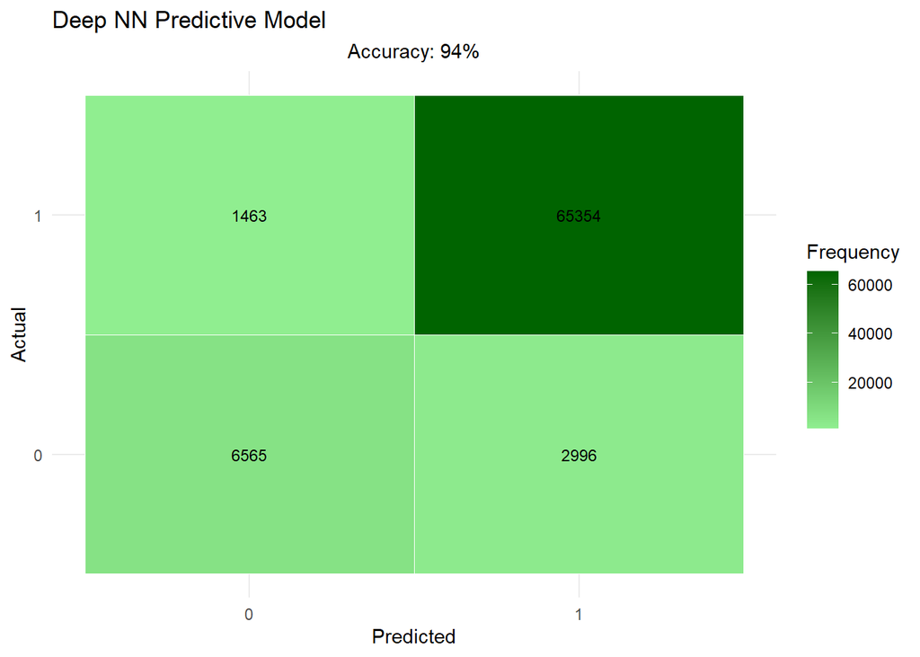

```r
# Calculate overall accuracy
overall_accuracy <- sum(diag(conf_matrix)) / sum(conf_matrix)

# Heatmap
heatmap_data <- as.data.frame(conf_matrix)
heatmap <- ggplot(heatmap_data, aes(x = Predicted, y = Actual, fill = Freq)) +
  geom_tile(color = "white") +
  scale_fill_gradient(low = "lightgreen", high = "darkgreen") +
  labs(x = "Predicted", y = "Actual", fill = "Frequency") +
  theme_minimal() +
  geom_text(aes(label = Freq), color = "black", size = 3) +  # Add text labels
  ggtitle("Deep NN Predictive Model") +  # Add title
  labs(subtitle = paste("Accuracy:", scales::percent(overall_accuracy))) +  # Add accuracy as subtitle
  theme(plot.subtitle = element_text(hjust = 0.5))  # Center subtitle

print(heatmap)
```

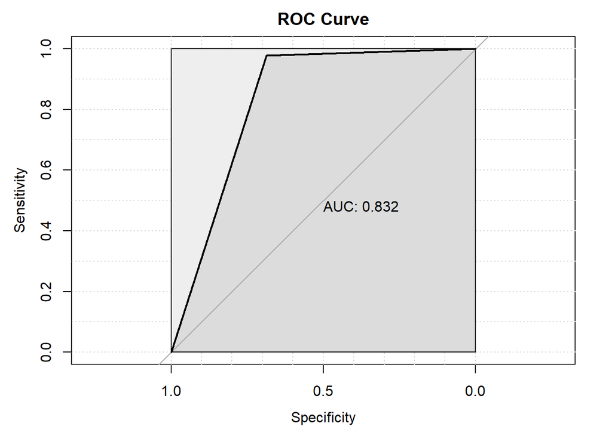

```r
# Plot ROC curve
roc_data <- roc(test_data$COD, predictions)
#plot(roc_data, main = "ROC Curve", col = "blue")
plot(roc_data, print.auc = TRUE, auc.polygon = TRUE, max.auc.polygon = TRUE, grid = TRUE, grid.col = "lightgray", main = "ROC Curve")
```

## Conclusion:

In this project, I aimed for prediction of the survival rate of patients with breast cancer with more than 96% accuracy knowing the survival rate is 75%. The goal was to use machine learning and available resources and the techniques learned in DATA606 and DTA607 to deal with this complex problem. I utilized the SEER database spanning from 2011 to 2015, comprising over 300,000 cases, to predict the survival rate of cancer patients based on 16 critical indicators, including race, household income, cancer type, treatment, time to treatment, number of tumors, and more. Preliminary exploratory data analysis was conducted to identify these key indicators from a pool of 36, followed by data cleaning and organization for machine learning tasks. Various R packages were employed for data cleaning, type conversion, handling missing values, and database organization. Additionally, correlation analyses using tools like ggplot, chi-square, Fisher test, and other complex R packages were performed to explore correlations between numeric and categorical variables and the target parameter of interest, Alive/Death.

Initially, the intention was to include all three categories of Alive/Death/Other, but it was later recognized that the inclusion of the “Other” category rendered the analysis irrelevant. Therefore, the analysis was focused solely on Alive/Death, as breast cancer was the primary cause of death even if patients had other conditions.

A range of machine learning algorithms were applied, starting from Logistic Regression and Random Forest to more sophisticated methods like DNN. Overall, the project demonstrated that even individuals with limited domain knowledge can utilize available resources to predict cancer patient outcomes with approximately 94% accuracy. However, further endeavors, such as stratification, parameter importance implication, and additional data gathering, could enhance accuracy, offering significant contributions to the healthcare industry, patient care, and family circumstances.

Despite the complexities associated with managing different packages and large databases, I enjoyed exploring new concepts and learning how different methods can be employed. Particularly, I gained insights into the significance of encoding and its impact on survival model performance. While this analysis lacks the rigor of academic research, it underscores the potential of machine learning in addressing complex problems, paving the way for future exploration and study.

This project highlights the potential of machine learning for patient survival prediction, even for individuals with limited domain knowledge. However, further research is needed to:

- **Enhance Accuracy:** Techniques like stratification, parameter importance analysis, and additional data acquisition can be explored.
- **Improve Generalizability:** Future studies could benefit from more diverse datasets and address the limitations of retrospective analysis.
- **Mitigate Black-Box Risks:** While DNNs offered promise, further exploration is required to understand their inner workings and enhance interpretability.

By addressing these limitations, future studies can contribute significantly to personalized medicine, patient care planning, and supporting families facing this challenging diagnosis.

## Acknowledgement:

I would like to thank the professors in both DATA606 and DATA607, as well as the students in the classes, who made the courses interesting and challenging. I have learned a lot and dealt with many challenges throughout these courses, despite having little specific background in data science beforehand. The course content was carefully chosen to help students like me develop an understanding of the topic and find enjoyment in the learning process.

## References:

[1] SEER (https://seer.cancer.gov/data/access.html)

[2] [zgalochkina/SEER_solid_tumor: R code for SEER data analysis of solid tumor in different populations (github.com)](https://github.com/zgalochkina/SEER_solid_tumor)

[3] [XAI_Healthcare_eXplainable_AI_in_Healthcare.pdf (upc.edu)](https://upcommons.upc.edu/bitstream/handle/2117/390006/XAI_Healthcare_eXplainable_AI_in_Healthcare.pdf?sequence=1)

[4] Pargen, F., Pfisterer, F., Thomas, J., Bischl, B.: Regularized target encoding out performs traditional methods in supervised machine learning with high cardinality features. Computational Statistics 37(5), 2671–2692 (Nov 2022)

[5] American Cancer Society - Breast Cancer Survival Rates

Surveillance, Epidemiology, and End Results Program. 2023. “SEER*stat Database: Incidence - SEER Research Data, 8 Registries, Nov 2021 Sub (1975-2020) - Linked to County Attributes - Time Dependent (1990-2020) Income/Rurality, 1969-2020 Counties.” National Cancer Institute, DCCPS, Surveillance Research Program, released April 2023, based on the November 2022 submission. https://seer.cancer.gov/data/citation.html.